# D.C. Resuscitation Collaborative

Hospital Outcome Report

D.C. Fire and EMS: Office of the Medical Director

August 26, 2021

# About

The D.C. Resuscitation Collaborative, Cardiac Arrest Hospital Outcome Report is an analysis of patients, who suffered a cardiac arrest and were transported by D.C. Fire and EMS to one of three hospitals in the District of Columbia:**Washington Hospital Center - MedStar**, **Howard University Hospital**, **George Washington University Hospital**.

Each hospital has specialty resources for cardiac emergencies that include the ability to perform PCI, or percutaneous coronary intervention to remove emboli or thrombus (a blockage) from coronary arteries to restore normal blood flow. Any blockage of the coronary arteries can lead to the irritation of heart muscle and in turn, result in abnormal electrical conduction which in turn leads to a sudden cardiac arrest event.

The System refers to the system of care outlined by the American Heart Association, better known as ‘*The Chain of Survival*’. Hospitals are part of the Advanced Resuscitation Care and Post-Event Recovery; two critical components to surviving a cardiac arrest event. This reports aims to provide a comprehensive analysis of the patients that are treated *and* transported to one of three PCI facilities in the District of Columbia.

# Definitions:

- Witnessed Cardiac Arrest: any cardiac arrest that was observed either by a healthcare provider, family member, or bystander
- Bystander CPR: defined as a true bystander (non-healthcare provider) or family member
- AED: Automated External Defibrillator
- ROSC: Return of Spontaneous Circulation
- Survival: Measured as survival to hospital discharge, without regard for cerebral performance category.
- Shockable Rhythm: Defined as either pulseless Ventricular Tachycardia, Ventricular Fibrillation, or Unknown Shockable Rhythm (obtained by AED data)

## Special Definitions:

- Utstein Criteria-1: Bystander witnessed cardiac arrest, with an initial presenting ‘shockable’ rhythm
- Utstein Criteria-2: Bystander witnessed cardiac arrest, with an initial presenting ‘shockable’ rhythm, and bystander CPR performed and/or applied an AED

# Data:

D.C. Fire and EMS uses the Cardiac Arrest Registry to Enhance Survival, also known as CARES, database to track and monitor all cardiac arrest resuscitations attempted by the Department. In the event a patient is transported to a hospital, each hospital is then responsible for entering outcome information into the registry.

For this analysis, all ‘non-traumatic’ cardiac arrests are included in the data set, and include the following etiologies: - Presumed Cardiac Etiology - Drug overdose - Respiratory arrest/asphyxia

The purpose of including all three etiologies is to alleviate issues with coding. It is unclear what the actual cause of a patients’ cardiac arrest and heavily relies on the pre-hospital providers to make that determination.

# Demographics

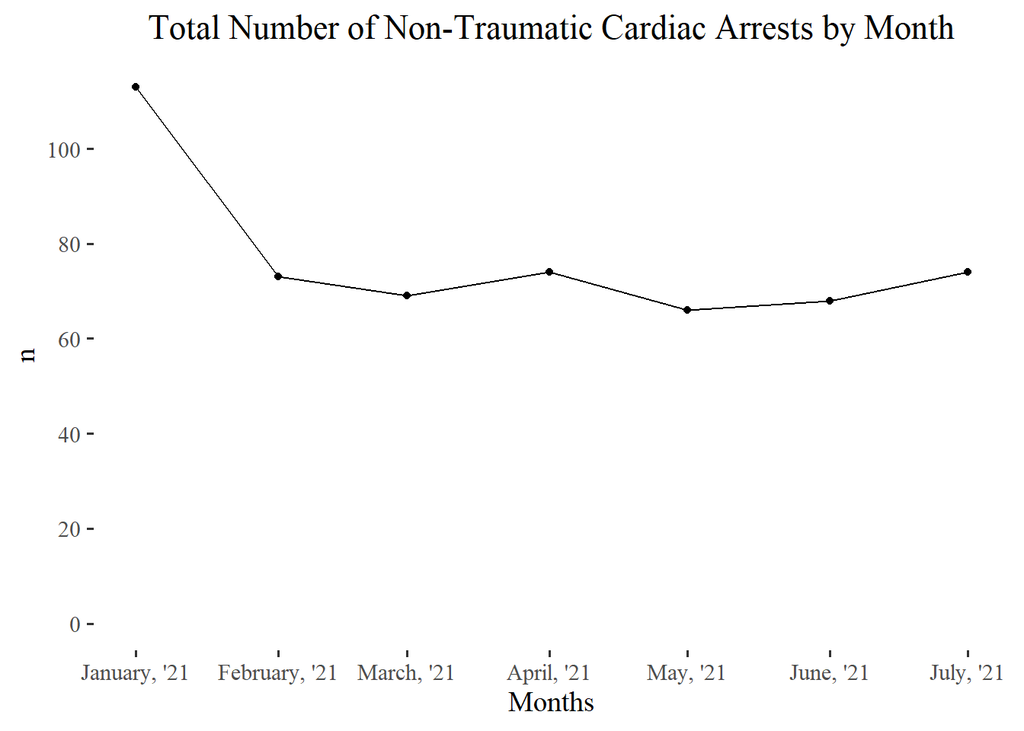

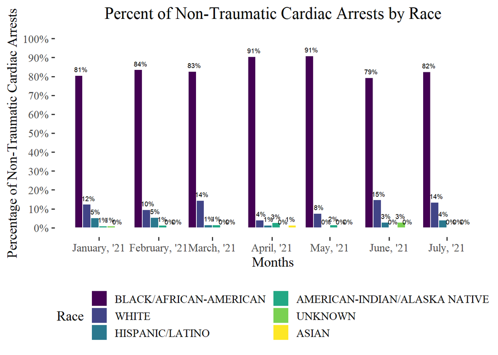

[output not shown]

[figure not shown]

```r
p4.1
```

[figure not shown]

```r
p4.2
```

[figure not shown]

```r
p4.3
```

[figure not shown]

```r
p5.1
```

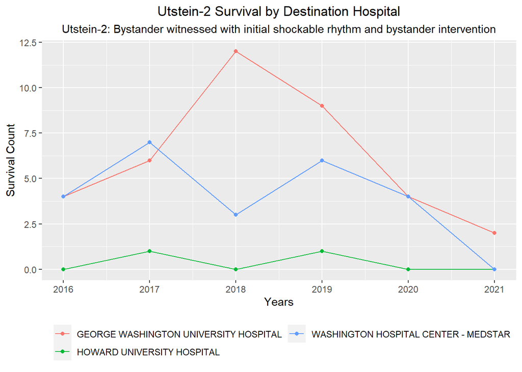

```r
p5.2
```

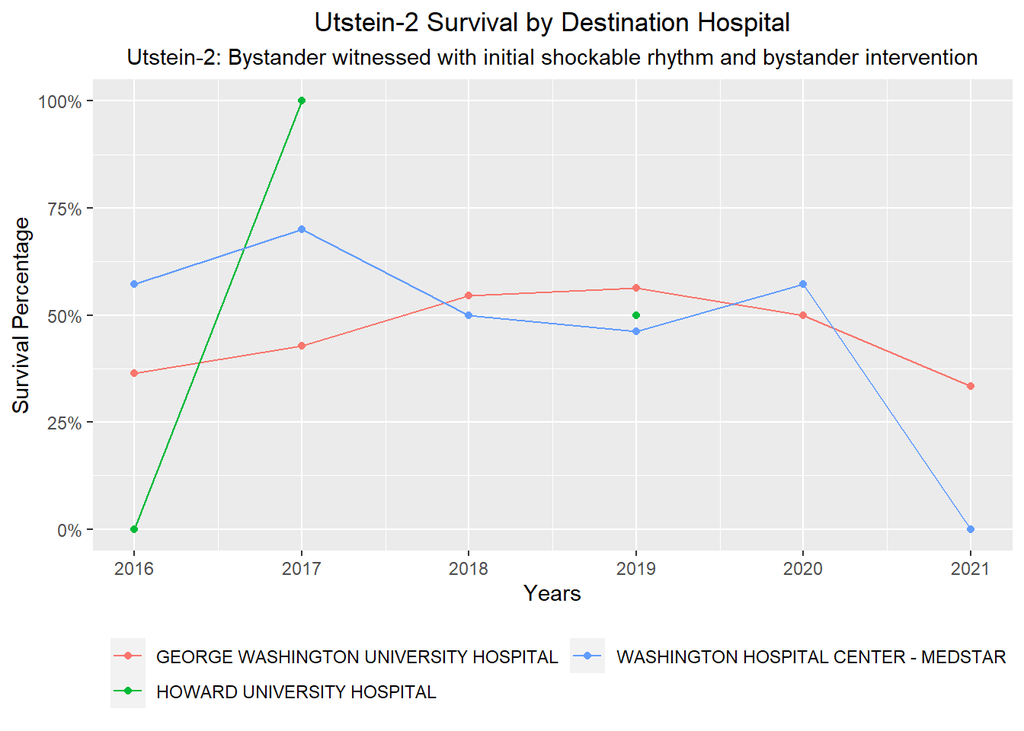

```r
p5.3
```

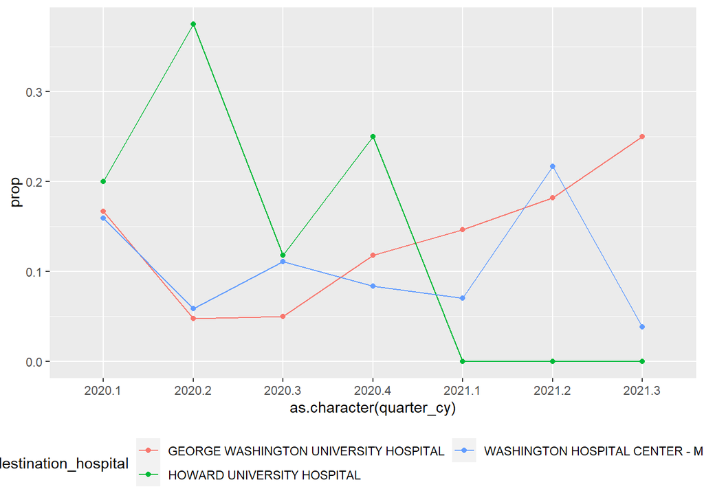

```r
p6.1
```